# Statistical Genetics - practical 1

install.packages(“data.table”)

for mac do this first: install.packages(“Rsolnp”, type = “binary”) ##

install.packages(“HardyWeinberg”)

```r
library(data.table)
library(HardyWeinberg)
```

# SNP dataset

## Loading dataset

```r
df <- read.table("TSICHR22RAW.raw", header = TRUE)

genetic_info <- df[, 7:ncol(df)]

geno_dt <- as.data.table(genetic_info)
```

## 1. How many variants are there in this database? What percentage of the data is missing?

```r
n_variants <- ncol(geno_dt)

cat("Number of variants:", n_variants, "\n")
```

```
## Number of variants: 20649
```

```r
pct_missing <- mean(is.na(geno_dt)) * 100
cat("Percentage missing:", round(pct_missing, 2), "%\n")
```

```
## Percentage missing: 0.2 %
```

## 2. Calculate the percentage of monomorphic variants. Exclude all monomorphics from the database for all posterior computations of the practical. How many variants do remain in your database?

Monomorphic means no variation, so we look for columns with same value all accross.

```r
n_unique <- geno_dt[, sapply(.SD, function(x) uniqueN(na.omit(x)))]
monomorphic <- n_unique <= 1
cat("Monomorphic %:", mean(monomorphic) * 100, "\n")
```

```
## Monomorphic %: 11.45818
```

```r
geno_poly <- geno_dt[, !monomorphic, with = FALSE]

n_poly <- ncol(geno_poly)
cat("Remaining variants:", n_poly, "\n")
```

```
## Remaining variants: 18283
```

```r
cat("Removed variants:", ncol(geno_dt)-n_poly, "\n")
```

```
## Removed variants: 2366
```

## 3. Report the genotype counts and the minor allele count of polymorphism rs8138488 C, and calculate the MAF of this variant.

```r
geno_counts <- geno_poly[, .N, by = rs8138488_C]
print(geno_counts)
```

```
##    rs8138488_C     N
##          <int> <int>
## 1:           0    41
## 2:           1    47
## 3:           2    14
```

```r
# genotype counts
g0 <- geno_poly[rs8138488_C == 0, .N]
g1 <- geno_poly[rs8138488_C == 1, .N]
g2 <- geno_poly[rs8138488_C == 2, .N]

# allel counts
n_ref <- 2 * g0 + g1
n_alt <- 2 * g2 + g1
n_total <- n_ref + n_alt

# allele frequencies
freq_ref <- n_ref / n_total
freq_alt <- n_alt / n_total

# MAF
MAF <- min(freq_ref, freq_alt)

cat("Genotype counts:\n")
```

```
## Genotype counts:
```

```r
cat("  0 (AA):", g0, "\n")
```

```
##   0 (AA): 41
```

```r
cat("  1 (AB):", g1, "\n")
```

```
##   1 (AB): 47
```

```r
cat("  2 (BB):", g2, "\n")
```

```
##   2 (BB): 14
```

```r
cat("Allele counts:\n")
```

```
## Allele counts:
```

```r
cat("  Reference:", n_ref, "\n")
```

```
##   Reference: 129
```

```r
cat("  Alternate:", n_alt, "\n")
```

```
##   Alternate: 75
```

```r
cat("Allele frequencies:\n")
```

```
## Allele frequencies:
```

```r
cat("  Reference:", round(freq_ref, 4), "\n")
```

```
##   Reference: 0.6324
```

```r
cat("  Alternate:", round(freq_alt, 4), "\n")
```

```
##   Alternate: 0.3676
```

```r
cat("MAF:", round(MAF, 4), "\n")
```

```
## MAF: 0.3676
```

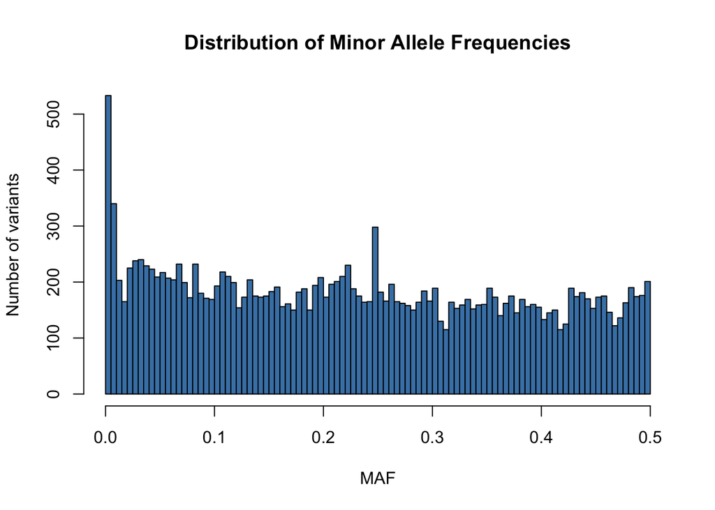

```r
# Function to compute MAF for one column
compute_maf <- function(x) {
  g0 <- sum(x == 0, na.rm = TRUE)
  g1 <- sum(x == 1, na.rm = TRUE)
  g2 <- sum(x == 2, na.rm = TRUE)
  n_ref <- 2 * g0 + g1
  n_alt <- 2 * g2 + g1
  n_total <- n_ref + n_alt
  if (n_total == 0) return(NA)
  min(n_ref, n_alt) / n_total
}

# Apply to all columns
maf <- sapply(geno_poly, compute_maf)


hist(maf,
     breaks = 100,
     col = "steelblue",
     main = "Distribution of Minor Allele Frequencies",
     xlab = "MAF",
     ylab = "Number of variants")
```

```r
# We can visually assess, but also Kolmogorov-Smirnov test against uniform too
ks.test(maf, "punif", min = 0, max = 0.5)
```

```
##
##  One-sample Kolmogorov-Smirnov test
##
## data:  maf
## D = 0.06309, p-value < 2.2e-16
## alternative hypothesis: two-sided
```

```r
# Below 0.05
pct_below_005 <- mean(maf < 0.05, na.rm = TRUE) * 100
cat("Percentage with MAF < 0.05:", round(pct_below_005, 2), "%\n")
```

```
## Percentage with MAF < 0.05: 14.23 %
```

```r
# Below 0.01
pct_below_001 <- mean(maf < 0.01, na.rm = TRUE) * 100
cat("Percentage with MAF < 0.01:", round(pct_below_001, 2), "%\n")
```

```
## Percentage with MAF < 0.01: 4.73 %
```

14.23 % of the variants have MAF lower than 0.05 and 4.73 % MAF lower than 0.01. These numbers indicate that there are around 4-14% of variants that happen very rarely

This means that a fraction of the variants in this population are rare variants. The fact that the percentage drops sharply when the threshold is lowered (from 14.23% to 4.73%) indicates that very rare variants are much less common than moderately rare ones. It is most likely for a variant to be common.

## 5. Calculate the observed heterozygosity H0, and make a histogram of it. What is, theoretically, the range of variation of this statistic?

At a given SNP, we have two chromosome copies of each parent. If those two copies have different alleles, it is heterozygous. So code 1 = heterozygous.

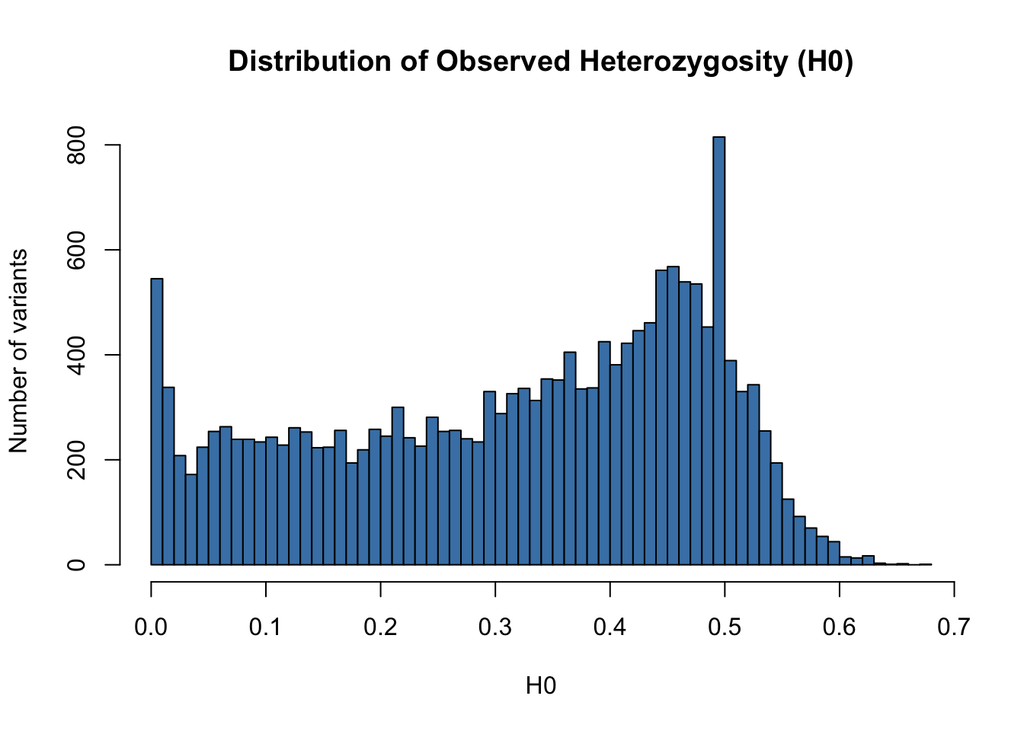

```r
# Function to compute H0 for one column
compute_h0 <- function(x) {
  x <- x[!is.na(x)]
  if (length(x) == 0) return(NA)
  mean(x == 1)
}

h0 <- geno_poly[, lapply(.SD, function(x) mean(x == 1, na.rm = TRUE))]
h0 <- unlist(h0)

hist(h0,
     breaks = 50,
     col = "steelblue",
     main = "Distribution of Observed Heterozygosity (H0)",
     xlab = "H0",
     ylab = "Number of variants")
```

Answer:

The theoretical range of this statistic is [0, 1], since it is possible that all individuals are Homozygous. In practice, we are seeing values much below 1 because it is rare for every individual in a sample to be heterozygous.

## Compute for each marker its expected heterozygosity (He). Make a histogram of the expected heterozygosity. What is, theoretically, the range of variation of this statistic? What is the average of He for this database?

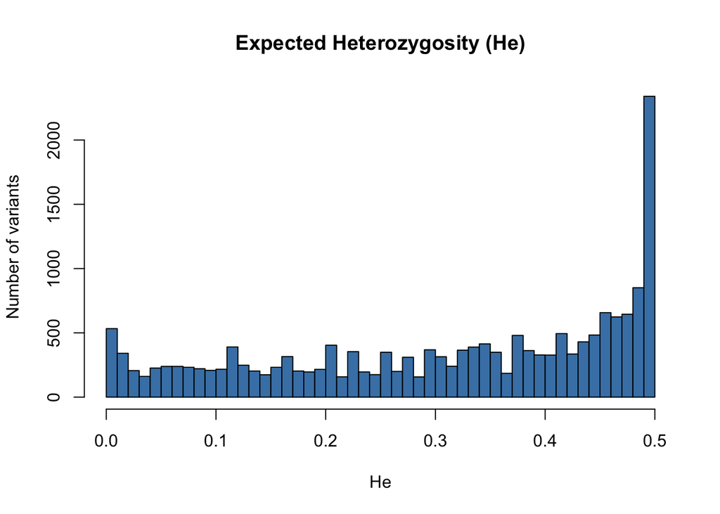

```r
# Function to compute He for one variant
compute_he <- function(x) {
  x <- x[!is.na(x)]
  g0 <- sum(x == 0)
  g1 <- sum(x == 1)
  g2 <- sum(x == 2)

  n_ref <- 2 * g0 + g1
  n_alt <- 2 * g2 + g1
  n_total <- n_ref + n_alt

  if (n_total == 0) return(NA)

  p_ref <- n_ref / n_total
  p_alt <- n_alt / n_total

  1 - (p_ref^2 + p_alt^2)
}

he <- geno_poly[, lapply(.SD, compute_he)]
he <- unlist(he)

hist(he,
     breaks = 50,
     col = "steelblue",
     main = "Expected Heterozygosity (He)",
     xlab = "He",
     ylab = "Number of variants")
```

```r
cat("Min He:", min(he, na.rm = TRUE), "\n")
```

```
## Min He: 0.009755863
```

```r
cat("Max He:", max(he, na.rm = TRUE), "\n")
```

```
## Max He: 0.5
```

```r
cat("Mean He:", mean(he, na.rm = TRUE), "\n")
```

```
## Mean He: 0.3115841
```

Answers: The theoretical range of He is [0, 0.5], with the maximum occurring when both alleles are equally frequent. In this database, the average He is 0.3116.

# STR dataset

```r
data(NistSTRs)

# Save to a data frame
str_df <- as.data.frame(NistSTRs)
```

## 1. How many individuals and how many STRs contains the database?

```r
cat("Individuals:", nrow(str_df), "\n")
```

```
## Individuals: 361
```

```r
cat("STRs:", ncol(str_df) / 2, "\n")
```

```
## STRs: 29
```

## 2. Write a function that determines the number of alleles for a STR. Determine the number of alleles for each STR in the database. Compute basic descriptive statistics of the number of alleles (mean, standard deviation, median, minimum, maximum).

```r
count_alleles <- function(allele1, allele2) {
  all_alleles <- c(allele1, allele2)
  all_alleles <- all_alleles[!is.na(all_alleles)]
  length(unique(all_alleles))
}

str_names <- unique(sub("-1$|-2$", "", colnames(str_df)))

n_alleles <- sapply(str_names, function(s) {
  count_alleles(str_df[[paste0(s, "-1")]], str_df[[paste0(s, "-2")]])
})


cat("Number of alleles per STR:\n")
```

```
## Number of alleles per STR:
```

```r
print(n_alleles)
```

```
##   CSF1PO D10S1248  D12S391  D13S317  D16S539   D18S51  D19S433  D1S1656
##        7        9       16        8        7       15       15       15
##   D21S11 D22S1045  D2S1338   D2S441  D3S1358   D5S818  D6S1043   D7S820
##       16        8       12       11        9        9       14        9
##  D8S1179   F13A01     F13B   FESFPS      FGA      LPL  Penta_C  Penta_D
##       10       12        6        7       14        8       10       13
##  Penta_E     SE33     TH01     TPOX      vWA
##       19       39        8        8       10
```

```r
cat("\nMean:", round(mean(n_alleles), 2), "\n")
```

```
##
## Mean: 11.86
```

```r
cat("SD:", round(sd(n_alleles), 2), "\n")
```

```
## SD: 6.23
```

```r
cat("Median:", median(n_alleles), "\n")
```

```
## Median: 10
```

```r
cat("Min:", min(n_alleles), "\n")
```

```
## Min: 6
```

```r
cat("Max:", max(n_alleles), "\n")
```

```
## Max: 39
```

## 3. Make a table with the number of STRs for a given number of alleles and present a barplot of the number STRs in each category. What is the most common number of alleles for an STR?

```r
allele_table <- table(n_alleles)
print(allele_table)
```

```
## n_alleles
##  6  7  8  9 10 11 12 13 14 15 16 19 39
##  1  3  5  4  3  1  2  1  2  3  2  1  1
```

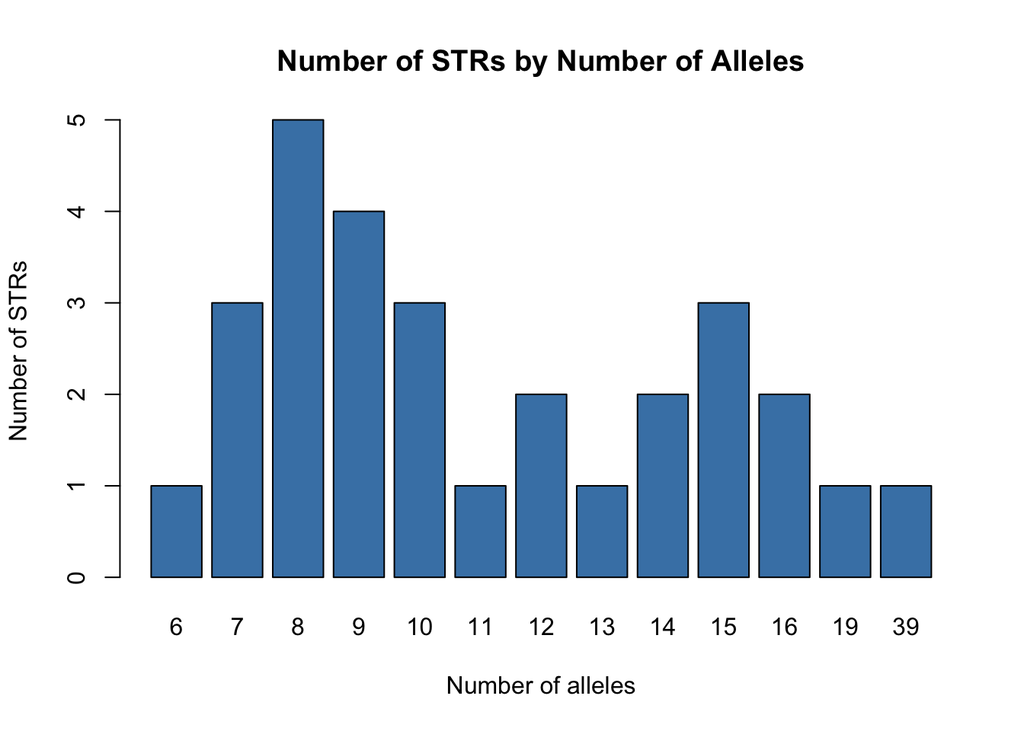

```r
barplot(allele_table,
        main = "Number of STRs by Number of Alleles",
        xlab = "Number of alleles",
        ylab = "Number of STRs",
        col = "steelblue")
```

```r
most_common <- as.numeric(names(allele_table)[which.max(allele_table)])
cat("Most common number of alleles:", most_common, "\n")
```

```
## Most common number of alleles: 8
```

## 4. Compute the expected heterozygosity for each STR. Make a histogram of the expected heterozygosity over all STRS. Compute the average expected heterozygosity over all STRs.

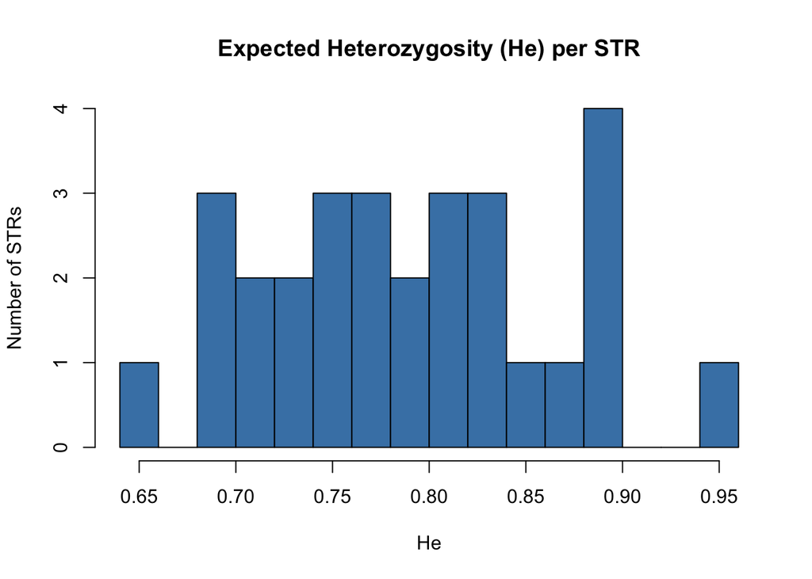

```r
compute_he_str <- function(allele1, allele2) {
  all_alleles <- c(allele1, allele2)
  all_alleles <- all_alleles[!is.na(all_alleles)]
  freqs <- table(all_alleles) / length(all_alleles)
  1 - sum(freqs^2)
}

str_names <- unique(sub("-1$|-2$", "", colnames(str_df)))

he_str <- sapply(str_names, function(s) {
  compute_he_str(str_df[[paste0(s, "-1")]], str_df[[paste0(s, "-2")]])
})

hist(he_str, breaks = 15, col = "steelblue",
     main = "Expected Heterozygosity (He) per STR",
     xlab = "He", ylab = "Number of STRs")
```

```r
cat("Average He:", round(mean(he_str), 4), "\n")
```

```
## Average He: 0.7904
```

## 5. Calculate also the observed heterozygosity for each STR. Plot observed against expected heterozygosity, using all STRs. What do you observe?

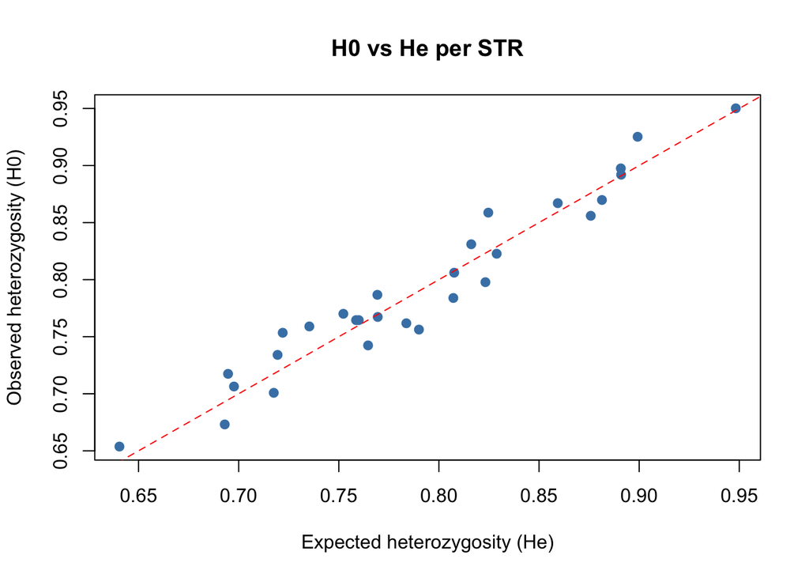

```r
compute_h0_str <- function(allele1, allele2) {
  valid <- !is.na(allele1) & !is.na(allele2)
  mean(allele1[valid] != allele2[valid])
}


h0_str <- sapply(str_names, function(s) {
  compute_h0_str(str_df[[paste0(s, "-1")]], str_df[[paste0(s, "-2")]])
})


plot(he_str, h0_str,
     xlab = "Expected heterozygosity (He)",
     ylab = "Observed heterozygosity (H0)",
     main = "H0 vs He per STR",
     pch = 19, col = "steelblue")
abline(0, 1, col = "red", lty = 2)
```

```r
fis <- (he_str - h0_str) / he_str
cat("Mean Fis:", round(mean(fis, na.rm = TRUE), 4), "\n")
```

```
## Mean Fis: -0.0024
```

Answer: Most points fall near the diagonal.

## 6. Compare, overall, the results you obtained for the SNP database with those you obtained for the STR database. What differences do you observe between these two types of genetic markers?

Answer:

The SNPs has more than 18000 markers, and show a mean expected heterozygosity of only 0.31 and a mix of rare and common variants. The STR database, by contrast, contains just 29 markers but each one is highly multi-allelic. This allows STRs to reach much higher heterozygosity levels, with a mean expected heterozygosity of 0.79.